# 자연언어처리 4주차_텍스트 마이닝을 사용한 자연언어처리 #2: 감성분석

고려대학교 일반대학원 심리학과

2022년 9월 26일 월요일 6-7교시

# 1. tidy 텍스트 형식 다루기

## (2) `unnest_tokens` 함수

### 1) 예시

```r
library(tidyverse)

# 현진건의 단편소설 중 일부를 벡터로 저장하기.
text_vec <- c("NC의 눈에서는 여태까지 보지 못하던 눈물이 흘렀습니다.",
              "NC의 가슴은 에이고 애탄의 결정인 뜨거운 눈물은 차디찬 옷깃을 적시고 식어 버리더이다.",
              "바다에는 진주가 있습니다." ,
              "우리 사람에게는 뜨겁게 반짝이는 눈물이 있습니다." ,
              "누가 이것을 보고 울지 않는 이가 있고 누가 이 꼴을 보고 눈물 홀리지 않는 이가 있을까요?"
)
text_vec
```

```
## [1] "NC의 눈에서는 여태까지 보지 못하던 눈물이 흘렀습니다."
## [2] "NC의 가슴은 에이고 애탄의 결정인 뜨거운 눈물은 차디찬 옷깃을 적시고 식어 버리더이다."
## [3] "바다에는 진주가 있습니다."
## [4] "우리 사람에게는 뜨겁게 반짝이는 눈물이 있습니다."
## [5] "누가 이것을 보고 울지 않는 이가 있고 누가 이 꼴을 보고 눈물 홀리지 않는 이가 있을까요?"
```

```r
# text_vec을 티블로 변환히기.
text_df <- tibble(line = 1:5, text = text_vec)
text_df
```

```
## # A tibble: 5 x 2
##    line text
##   <int> <chr>
## 1     1 NC의 눈에서는 여태까지 보지 못하던 눈물이 흘렀습니다.
## 2     2 NC의 가슴은 에이고 애탄의 결정인 뜨거운 눈물은 차디찬 옷깃을 적시고 식~
## 3     3 바다에는 진주가 있습니다.
## 4     4 우리 사람에게는 뜨겁게 반짝이는 눈물이 있습니다.
## 5     5 누가 이것을 보고 울지 않는 이가 있고 누가 이 꼴을 보고 눈물 홀리지 않는~
```

### 2) 논항 1: `token`

- `input`: 토큰화를 위해 투입되는 텍스트 입력 열.
- `output`: 토큰화 이후의 출력 열.
- `token`: 토큰화의 유형. `"words"`를 택하면 단어(띄어쓰기) 단위로 토큰화됨.

#### A. 단일 단어

- 단어 단위로 토큰화하기: `token` 논항으로 `"words"` 입력.

```r
library(tidytext)

# 단어 단위로 토큰화하기.
text_df %>%
  unnest_tokens(output = word, input = text, token = "words")
```

```
## # A tibble: 46 x 2
##     line word
##    <int> <chr>
##  1     1 nc
##  2     1 의
##  3     1 눈에서는
##  4     1 여태까지
##  5     1 보지
##  6     1 못하던
##  7     1 눈물이
##  8     1 흘렀습니다
##  9     2 nc
## 10     2 의
## # ... with 36 more rows
```

#### B. n-그램

- n-그램 단위로 토큰화하기: `token` 논항으로 `"ngrams"` 입력.

```r
# 바이그램 단위로 토큰화하기.
text_df %>%
  unnest_tokens(output = word, input = text, token = "ngrams", n = 2)
```

```
## # A tibble: 41 x 2
##     line word
##    <int> <chr>
##  1     1 nc 의
##  2     1 의 눈에서는
##  3     1 눈에서는 여태까지
##  4     1 여태까지 보지
##  5     1 보지 못하던
##  6     1 못하던 눈물이
##  7     1 눈물이 흘렀습니다
##  8     2 nc 의
##  9     2 의 가슴은
## 10     2 가슴은 에이고
## # ... with 31 more rows
```

#### C. 단일 글자/음절

```r
# 단일 글자/음절 단위로 토큰화한 뒤 토큰의 빈도 분석하기.
text_df %>%
  unnest_tokens(output = word, input = text, token = "characters") %>%
  count(word, sort = T)
```

```
## # A tibble: 65 x 2
##    word      n
##    <chr> <int>
##  1 이        9
##  2 가        6
##  3 는        6
##  4 고        5
##  5 눈        5
##  6 다        5
##  7 물        4
##  8 에        4
##  9 을        4
## 10 있        4
## # ... with 55 more rows
```

#### D. 여러 글자/음절

- 여러 글자/음절 단위로 토큰화하기
  - `token` 논항으로 `"character_shingles"` 입력.
  - 영어는 글자 단위, 한국어는 음절 단위로 토큰화됨.

```r
# 두 글자/음절 단위로 토큰화한 뒤 토큰의 빈도 분석하기.
text_df %>%
  unnest_tokens(output = word, input = text, token = "character_shingles", n = 2) %>%
  count(word, sort = T)
```

```
## # A tibble: 102 x 2
##    word      n
##    <chr> <int>
##  1 눈물      4
##  2 가있      3
##  3 니다      3
##  4 습니      3
##  5 c의       2
##  6 nc        2
##  7 가이      2
##  8 누가      2
##  9 는이      2
## 10 물이      2
## # ... with 92 more rows
```

#### E. 정규표현식

- 정규표현식을 사용하여 사용자가 원하는 단위로 토큰화하기
  - `token` 논항으로 `"regex"` 입력
  - `pattern` 논항으로 원하는 정규표현식 입력.

```r
# 개행 "\n" 단위로 토큰화하기.
text_df %>%
  unnest_tokens(output = word, input = text, token = "regex", pattern = "\n")
```

```
## # A tibble: 5 x 2
##    line word
##   <int> <chr>
## 1     1 nc의 눈에서는 여태까지 보지 못하던 눈물이 흘렀습니다.
## 2     2 nc의 가슴은 에이고 애탄의 결정인 뜨거운 눈물은 차디찬 옷깃을 적시고 식~
## 3     3 바다에는 진주가 있습니다.
## 4     4 우리 사람에게는 뜨겁게 반짝이는 눈물이 있습니다.
## 5     5 누가 이것을 보고 울지 않는 이가 있고 누가 이 꼴을 보고 눈물 홀리지 않는~
```

```r
# "+" 단위로 토큰화하기.
text_df %>%
  mutate(text = str_replace_all(text, " ", "+")) %>%
  unnest_tokens(output = word, input = text, token = "regex", pattern = "\\+")
```

```
## # A tibble: 44 x 2
##     line word
##    <int> <chr>
##  1     1 nc의
##  2     1 눈에서는
##  3     1 여태까지
##  4     1 보지
##  5     1 못하던
##  6     1 눈물이
##  7     1 흘렀습니다.
##  8     2 nc의
##  9     2 가슴은
## 10     2 에이고
## # ... with 34 more rows
```

### 3) 논항 2: `to_lower`

- 영문 알파벳 대문자의 소문자화 여부를 결정하는 논항
  - 기본값: `to_lower = TRUE`.
  - `FALSE`로 지정 시 대문자를 소문자로 변경하지 않음. 인명이나 지명 같은 고유명사 구분 필요 시 `FALSE`로 지정할 것.

```r
# 영문 알파벳 대문자를 소문자로 변경하지 않기.
text_df %>%
  unnest_tokens(output = word, input = text, token = "words", to_lower = FALSE)
```

```
## # A tibble: 46 x 2
##     line word
##    <int> <chr>
##  1     1 NC
##  2     1 의
##  3     1 눈에서는
##  4     1 여태까지
##  5     1 보지
##  6     1 못하던
##  7     1 눈물이
##  8     1 흘렀습니다
##  9     2 NC
## 10     2 의
## # ... with 36 more rows
```

### 4) 논항 3: `strip_punct`

- 문장부호 제거 여부 결정: `TRUE` 설정 시 문장부호 제거.

```r
# 문장부호 제거한 경우.
text_df %>%
  unnest_tokens(output = word, input = text, token = "words", strip_punct = TRUE)
```

```
## # A tibble: 46 x 2
##     line word
##    <int> <chr>
##  1     1 nc
##  2     1 의
##  3     1 눈에서는
##  4     1 여태까지
##  5     1 보지
##  6     1 못하던
##  7     1 눈물이
##  8     1 흘렀습니다
##  9     2 nc
## 10     2 의
## # ... with 36 more rows
```

```r
# 문장부호 제거하지 않은 경우.
text_df %>%
  unnest_tokens(output = word, input = text, token = "words", strip_punct = FALSE)
```

```
## # A tibble: 51 x 2
##     line word
##    <int> <chr>
##  1     1 nc
##  2     1 의
##  3     1 눈에서는
##  4     1 여태까지
##  5     1 보지
##  6     1 못하던
##  7     1 눈물이
##  8     1 흘렀습니다
##  9     1 .
## 10     2 nc
## # ... with 41 more rows
```

## (3) 불용어(stop words) 목록

### 1) 불용어 목록

- 불용어
  - 정의: 분석에 사용되지 않는 단어.
  - 종류: 빈도가 높아 분석에 유용하지 않은 단어. 영어의 전치사가 대표적인 예. 비내용어([EX] 숫자, 특수문자, 구두점, 공백문자, 기호)도 포함 가능.
  - 불용어의 선정 방법
    - 범용: 일반적으로 대부분의 텍스트 분석에 널리 적용 가능한 불용어 목록을 사용하는 경우.
    - 사용자 정의: 분석의 목적에 따라 사용자가 직접 정의하는 경우. 대명사는 대부분의 불용어 목록에 포함되어 있지만, 필요에 따라 분석의 대상이 될 수도 있음.

#### 1) 영어

- `tidytext` 내장 불용어 목록: `data(stop_words)`를 불러와 사용 가능.

```r
# 영어 불용어 목록 불러오기.
data(stop_words)
stop_words
```

```
## # A tibble: 1,149 x 2
##    word        lexicon
##    <chr>       <chr>
##  1 a           SMART
##  2 a's         SMART
##  3 able        SMART
##  4 about       SMART
##  5 above       SMART
##  6 according   SMART
##  7 accordingly SMART
##  8 across      SMART
##  9 actually    SMART
## 10 after       SMART
## # ... with 1,139 more rows
```

#### 2) 한국어

- 길호현(2018)의 한국어 불용어 목록: 자세한 불용어 목록 추출 절차는 해당 논문 참조.

**[그림 2] 길호현(2018)의 한국어 불용어 목록**

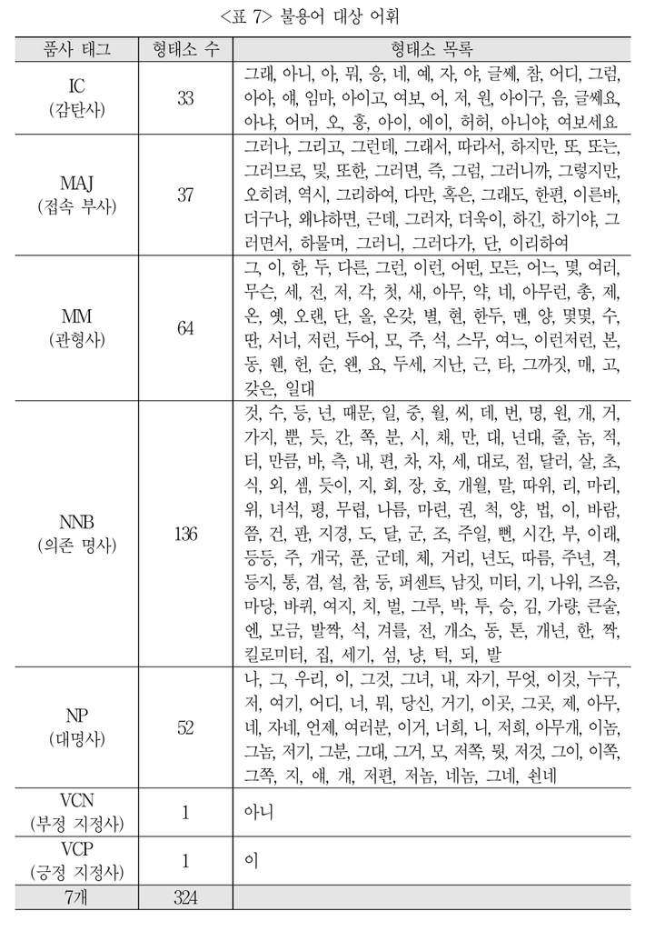

```r
# 불용어 목록 저장 경로 지정하기.
stop_words.1.path <- "texts/stop_words/텍스트마이닝을 위한 한국어 범용 불용어 목록 연구_노성화 & 김정 (2022).txt"
stop_words.2.path <- "texts/stop_words/텍스트마이닝을 위한 한국어 불용어 목록 연구_길호현 (2018).txt"

# 티블 형식으로 불용어 목록 만들기.
stop_words_gil <- readLines(stop_words.2.path, encoding = "UTF-8") %>%
  str_split(", ") %>%
  unlist() %>%
  as_tibble() %>%
  rename(word = value) %>%
  mutate(lexicon = "Gil")
stop_words_gil
```

```
## # A tibble: 293 x 2
##    word  lexicon
##    <chr> <chr>
##  1 가량  Gil
##  2 가지  Gil
##  3 각    Gil
##  4 간    Gil
##  5 갖은  Gil
##  6 개    Gil
##  7 개국  Gil
##  8 개년  Gil
##  9 개소  Gil
## 10 개월  Gil
## # ... with 283 more rows
```

- 노성화 & 김정(2022)의 한국어 범용 불용어 목록: 자세한 불용어 목록 추출 절차는 해당 논문 참조.

**[그림 2] 노성화 & 김정(2022)의 한국어 불용어 목록**

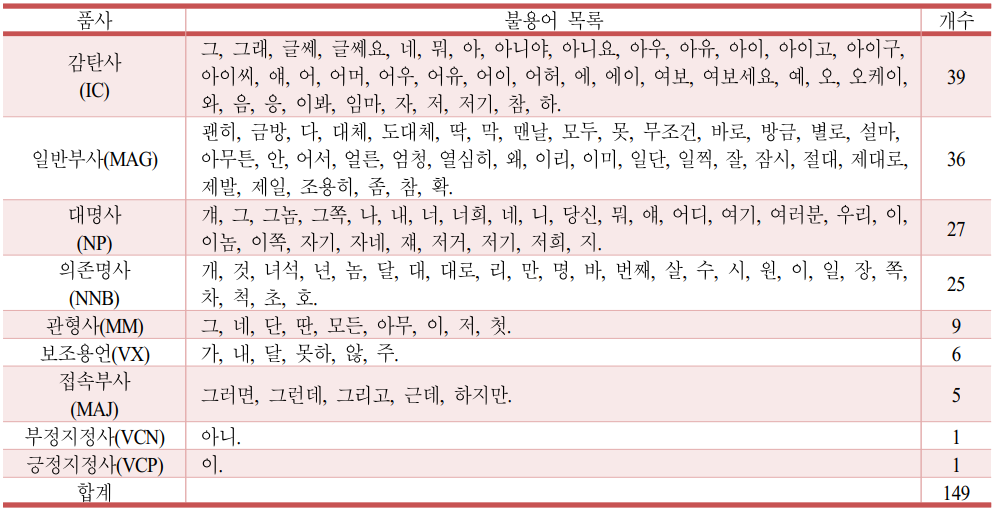

```r
# 티블 형식으로 불용어 목록 반들기.
stop_words_no_kim <- readLines(stop_words.1.path, encoding = "UTF-8") %>%
  str_split(", ") %>%
  unlist() %>%
  as_tibble() %>%
  rename(word = value) %>%
  mutate(lexicon = "No_Kim")
stop_words_no_kim
```

```
## # A tibble: 149 x 2
##    word   lexicon
##    <chr>  <chr>
##  1 그래   No_Kim
##  2 글쎄   No_Kim
##  3 글쎄요 No_Kim
##  4 네     No_Kim
##  5 뭐     No_Kim
##  6 아     No_Kim
##  7 아니야 No_Kim
##  8 아이   No_Kim
##  9 아이고 No_Kim
## 10 아이구 No_Kim
## # ... with 139 more rows
```

- 두 불용어 목록 하나로 합치기

```r
# 두 개의 불용어 목록을 한국어 불용어 목록 하나로 합치기.
stop_words_korean <- bind_rows(stop_words_no_kim, stop_words_gil)
stop_words_korean
```

```
## # A tibble: 442 x 2
##    word   lexicon
##    <chr>  <chr>
##  1 그래   No_Kim
##  2 글쎄   No_Kim
##  3 글쎄요 No_Kim
##  4 네     No_Kim
##  5 뭐     No_Kim
##  6 아     No_Kim
##  7 아니야 No_Kim
##  8 아이   No_Kim
##  9 아이고 No_Kim
## 10 아이구 No_Kim
## # ... with 432 more rows
```

### 2) 불용어 목록 제외한 단어 빈도 계산하기

- 실습대상 말뭉치: 모두의 말뭉치 비출판물(NIKL_NP_v1.1). 주로 일반인의 수필이나 소설 습작으로 구성됨.

```r
# XML 형식 파일을 R로 반입하는 패키지 XML 불러오기.
library(XML)

# 목록 내 XML 파일 일괄적으로 읽어들이는 함수 자체 제작하기.
xml.import <- function(xml){
  x <- read_lines(xml) %>% # tidyverse의 read_lines 함수로 먼저 불러들이기.
    str_replace_all(" > |&", "") %>% # 일괄적으로 XML 파일을 읽어들일 때
    # 문제가 되는 기호 ">", "&"(ampersand) 제거하기.
    xmlParse() # XML 파일 parsing하기.
  y <- xmlToDataFrame(nodes = getNodeSet(x, "//text")) %>% # "text" 노드만 선택하여 데이터 프레임으로 변환하기.
    t() %>% # 행을 열로 & 열을 행으로 바꿔주는 R 내장 함수.
    as_tibble() %>%
    rename(text_segment = V1) %>%
    mutate(paragraph = row_number()) # 단락번호 추가.
  z <- xmlToDataFrame(nodes = getNodeSet(x, "//title")) %>% # "title" 노드만 선택하여 데이터 프레임으로 변환하기.
    t() %>% # 행을 열로 & 열을 행으로 바꿔주는 R 내장 함수.
    as_tibble() %>%
    rename(title = V1)
  a <- bind_cols(z, y)
}

# 300개 XML 파일 비출판물 텍스트 리스트 생성하기.
xml.list <- list.files(path = "texts/xml", pattern = "sjml$", recursive = T)
xml.list.1 <- paste0("texts/xml/", xml.list)
xml.list.1[1:10]
```

```
##  [1] "texts/xml/WDRW1900100013.sjml" "texts/xml/WDRW1900100015.sjml"
##  [3] "texts/xml/WDRW1900100023.sjml" "texts/xml/WDRW1900100027.sjml"
##  [5] "texts/xml/WDRW1900100031.sjml" "texts/xml/WDRW1900100037.sjml"
##  [7] "texts/xml/WDRW1900100040.sjml" "texts/xml/WDRW1900100044.sjml"
##  [9] "texts/xml/WDRW1900100046.sjml" "texts/xml/WDRW1900100053.sjml"
```

```r
# xml.import 함수를 사용하여 리스트 내 XML 파일 티블 형식으로 일괄 변환하기.
xml.import.1 <- map_dfr(xml.list.1, function(x) xml.import(x))
xml.import.1
```

```
## # A tibble: 3,621 x 3
##    title         text_segment                                          paragraph
##    <chr>         <chr>                                                     <int>
##  1 아내의 생일상 어제는 아내의 생일이었다. 생일을 맞이하여 아침을 준~          1
##  2 아내의 생일상 주된 메뉴는 스테이크와 낙지볶음, 미역국, 잡채, 소야 ~         2
##  3 아내의 생일상 그런데 상상도 못한 일이 벌이지고 말았다. 보통 시즈닝~         3
##  4 아내의 생일상 앞면을 센불에 1분을 굽고 뒤집는 순간 방부제가 함께 ~          4
##  5 아내의 생일상 어처구니 없는 상황이 발생한 것이다. 방부제가 센불에 ~         5
##  6 아내의 생일상 방부제가 묻은 부문만 제거 하고 다시 구울까 했는데 방~         6
##  7 아내의 생일상 하지만 정신을 추스리고 바로 다른 메뉴로 변경했다. 소~         7
##  8 아내의 생일상 음식은 성공적으로 완성이 되었다. 40번째를 맞이하는 ~          8
##  9 아내의 생일상 오늘도 즐거운 하루가 되었으면 좋겠다. 생일이니까~             9
## 10 소금이 온다   나는소금이 나오는 게곡에 가보고 싶어진다.                     1
## # ... with 3,611 more rows
```

- 불용어 목록 제외 전 vs. 후 단어 빈도 비교하기.

```r
# 불용어 목록 제외 전 단어 빈도 분석하기.
xml.import.2 <- xml.import.1 %>%
  unnest_tokens(word, text_segment, strip_punct = T) %>%
  count(word, sort = TRUE) # word의 빈도 분석(SORT = TRUE: 내림차순으로 배열).
xml.import.2
```

```
## # A tibble: 39,574 x 2
##    word      n
##    <chr> <int>
##  1 수      741
##  2 그      702
##  3 나는    621
##  4 내가    493
##  5 있는    418
##  6 이      383
##  7 한      371
##  8 더      369
##  9 내      362
## 10 것      344
## # ... with 39,564 more rows
```

```r
# 불용어 목록 제외 후 단어 빈도 분석하기
xml.import.3 <- xml.import.1 %>%
  unnest_tokens(word, text_segment, strip_punct = T) %>%
  anti_join(stop_words_korean) %>% # anti_join 함수를 통해 불용어 목록에 포함된 단어만 제거하기.
  count(word, sort = TRUE)
xml.import.3
```

```
## # A tibble: 39,296 x 2
##    word       n
##    <chr>  <int>
##  1 나는     621
##  2 내가     493
##  3 있는     418
##  4 더       369
##  5 있다     261
##  6 있었다   259
##  7 하고     251
##  8 것이다   238
##  9 하는     238
## 10 것이     210
## # ... with 39,286 more rows
```

- 불용어 제거 방법
  - `anti_join` 함수 사용: 불용어 목록과 목표 텍스트를 `word`(토큰) 기준으로 병합하되, 불용어에 있는 단어는 제거할 것.
  - `filter` 함수 사용: `str_detect` 함수 및 부정연산자 `!`와 결합하여 추가로 불용어를 걸러낼 수 있음.

```r
# anti_join과 filter 함수를 함께 사용하여 불용어 "것"으로 시작하는 단어 추가로 제거하기.
xml.import.4 <- xml.import.1 %>%
  unnest_tokens(word, text_segment, strip_punct = T) %>%
  anti_join(stop_words_korean) %>%
  filter(!str_detect(word, "것+.*")) %>% # "것"으로 시작하는 단어를 찾아낸 뒤 filter 함수에 !를 더하여 제거하기.
  count(word, sort = TRUE)
xml.import.4
```

```
## # A tibble: 38,989 x 2
##    word       n
##    <chr>  <int>
##  1 나는     621
##  2 내가     493
##  3 있는     418
##  4 더       369
##  5 있다     261
##  6 있었다   259
##  7 하고     251
##  8 하는     238
##  9 할       196
## 10 했다     194
## # ... with 38,979 more rows
```

## (4) 정규화(normalization)하기

- 정의: 추출된 단어를 일정한 형식으로 규격화화는 절차.
- 의의: “마시다”는 다양한 활용형([EX]“마셔서”, “마셨군”, “마실”)를 지님. 다양한 활용형이 같은 의미를 나타낸다면 정규화를 통해 일정한 형식으로 규격화한ㄴ 작업이 필요.
- 대표적인 종류
  - 단어(word): 자립이 가능한 최소 언어단위. [EX] 책상, 먹었다.
  - 형태소(morpheme): 의미 또는 기능을 지닌 최소 언어단위. [EX] 먹(어간) + 었(선어말어미) + 다(종결어미).

### 1) 단어 단위

- 한국어의 경우, 기존 띄어쓰기(어절) 단위에 해당.

### 2) 형태소 단위

#### A. **KoNLP**로 형태소 분석하기

- 주요 함수
  - `useSejongDic()`: **KoNLP** 패키지 사용을 위해 세종 말뭉치 기반 사전 불러오기.
  - `SimplePos09`
    - KAIST 9품사 태그셋에 기초한 형태분석 시행.
    - 입력: 문자열만 가능.
    - 출력: 결과를 리스트로 반환.
    - 논항: `autoSpacing = T`를 추가하면 띄어쓰기를 자동으로 해줌. 그러나 성능이 뛰어나지는 않음.
  - `SimplePos22`
    - KAIST 22품사 태그셋에 기초한 형태분석 시행.
    - 입력: 문자열만 가능.
    - 출력: 결과를 리스트로 반환.
    - 논항: `autoSpacing = T`를 추가하면 띄어쓰기를 자동으로 해줌. 그러나 성능이 뛰어나지는 않음.

**[그림 3] KAIST 품사 태그셋**

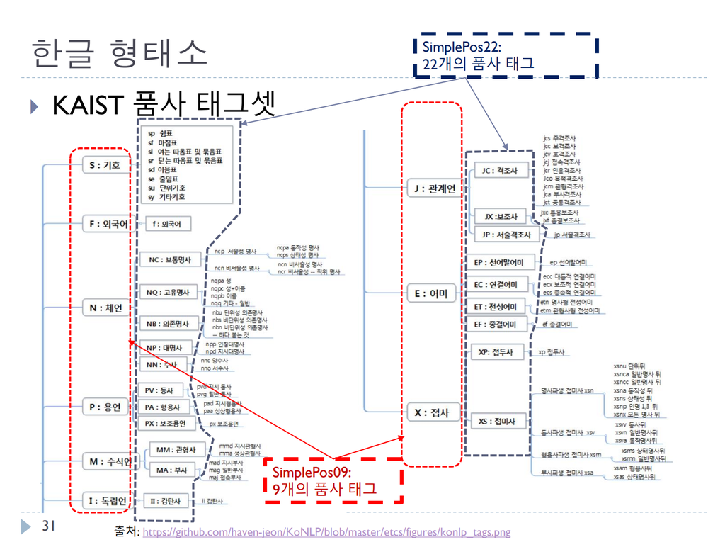

```r
library(KoNLP)
useSejongDic() # 사전 불러오기.
```

```
## Backup was just finished!
## 370957 words dictionary was built.
```

```r
xml.import.tagged <- xml.import.1$text_segment %>% # KoNLP는 문자열 단위로 형태소를 분석해줌. 따라서 티블을 통째로 넣어선 안 됨.
  SimplePos22() %>% # 형태소 분석 함수 적용하기.
  unlist() %>% # 리스트를 벡터화하기.
  as_tibble() %>% # 벡터를 티블로 변환하기.
  separate_rows(value, sep = "\\+")  %>% # "+" 단위로 행 분리하기.
  separate(value, into = c("word", "pos"), sep = "/") %>% # "/" 기호를 기준으로 word와 pos 열로 나누기.
  filter(!str_detect(pos, "J[A-Z]{1,3}|E[A-Z]{1,3}|S[A-Z]{1,3}")) %>% # 조사, 어미, 기호 제외.
  unnest_tokens(word, word, token = "words", strip_punct = T) %>% # 형태소 단위로 토큰화.
  anti_join(stop_words_korean) %>% # 한국어 불용어 목록 제외.
  count(word, sort = T) # 최종 단어 빈도 분석.
xml.import.tagged
```

```
## # A tibble: 16,415 x 2
##    word      n
##    <chr> <int>
##  1 있     2292
##  2 보     1222
##  3 들      891
##  4 없      838
##  5 생각    743
##  6 같      693
##  7 사람    559
##  8 때      537
##  9 좋      518
## 10 많      484
## # ... with 16,405 more rows
```

#### B. **RcppMeCab**으로 형태소 분석하기

- **RcppMeCab** 패키지의 `pos` 함수를 `token` 논항에 넣어 토큰화의 한 방법으로 활용 가능: **RcppMeCab**으로 분석된 형태소가 토큰화의 단위가 됨.
- 주의사항: RcppMeCab은 KoNLP보다 정확성은 우수하나, 용언의 어간 + 어미를 물리적으로 분리해주지 않는다는 단점이 있음.
- 주요 함수
  - `pos` 함수
    - 개관
      - 기본 형태소 분석 함수. 문자열 벡터를 분석하여 형태소 태그를 부착해줌.
      - 장점: 띄어쓰기가 불완전해도 알아서 어절 단위로 분할해줌.
      - 단점: 용언 + 어미 어절은 형태소 태그를 부착해주나, 둘을 분해해주지는 않음.
    - 논항
      - `join = T`: 디폴트가 `TRUE`임. “형태소/품사” 형태로 결과 반환.
      - `format = data.frame`
        - 디폴트가 리스트임. 데이터 프레임 형식으로 결과 반환.
        - `analytic`이라는 열에서 용언 + 어미 어절을 분해해줌.
  - `posParrell` 함수
    - `pos`와 같은 기능을 수행하지만, 다중 스레딩을 지원해줌.
    - 속도는 빠르나, 그만큼 메모리 소모도 많음.
    - 논항은 `pos`와 동일.

```r
library(RcppMeCab)
xml.import.1 %>%
  mutate(text_segment = enc2utf8(text_segment)) %>% # R 내장함수인 enc2utf8을 통해 text_segment 열의 텍스트를 UTF-8 형식으로 인코딩하기(그래야 한글이 깨지지 않음!).
  unnest_tokens(word, text_segment, token = RcppMeCab::pos) # 토큰화 빙식으로 RcppMeCab 패키지의 형태소 분석 함수인 pos를 투입.
```

```
## # A tibble: 220,024 x 3
##    title         paragraph word
##    <chr>             <int> <chr>
##  1 아내의 생일상         1 어제/nng
##  2 아내의 생일상         1 는/jx
##  3 아내의 생일상         1 아내/nng
##  4 아내의 생일상         1 의/jkg
##  5 아내의 생일상         1 생일/nng
##  6 아내의 생일상         1 이/vcp
##  7 아내의 생일상         1 었/ep
##  8 아내의 생일상         1 다/ef
##  9 아내의 생일상         1 ./sf
## 10 아내의 생일상         1 생일/nng
## # ... with 220,014 more rows
```

## (5) 작가 이상의 작품 분석하기

### 1) 이상의 작품이 수록된 직지 프로젝트 파일 내려받기

- **epubr** 패키지를 사용하여 직지 프로젝트 파일(저작권이 만료된 일제 강점기 단편소설 모음) R로 반입하기.

```r
library(epubr) # epub 파일을 R로 반입해주는 패키지 epubr 불러들이기.

# epub 함수를 사용하여 jikji.epub 파일 반입하기.
epub.text <- epub("texts/epub/jikji.epub") %>%
  .$data %>%
  .[[1]] %>%
  .$text

# 제목 추출하기.
title <- epub.text %>%
  str_extract(".*\\b") # 어떤 문자든 0회 이상 출현하고 단어의 경계(boundary)로 끝나는 최초 문자열 추출하기.
title
```

```
##  [1] "17원 50전(十七圓五十錢)--- 젋은 화가 A의 눈물 한 방울"
##  [2] "B사감(舍監)과 러브레터"
##  [3] "경희(瓊姬"
##  [4] "계집 하인"
##  [5] "고향"
##  [6] "공포(恐怖)의 기록(記錄"
##  [7] "광화사(狂畵師"
##  [8] "구운몽(완판 105장본) 현대문"
##  [9] "권태"
## [10] "규원"
## [11] "그립은 흘긴 눈"
## [12] "금따는 콩밭"
## [13] "금붕어"
## [14] "김탄실과 그 아들"
## [15] "까막잡기"
```

[output cut: 78 more lines]

```r
# 저자 추출하기.
author <- epub.text %>%
  str_extract("지은이.*\\b") %>%  # "지은이"에 이어 어떤 문자든 0회 이상 나오고 단어의 경계로 끝나는 최초 문자열 추출하기.
  str_remove("지은이: ") # "지은이: " 지우기. str_replace("지은이: ", "")와 동일한 기능 수행.
author
```

```
##  [1] "나도향" "현진건" "나혜석" "나도향" "현진건" "이상"   "김동인" "김만중"
##  [9] "이상"   "나혜석" "현진건" "김유정" "전영택" "전영택" "현진건" "이효석"
## [17] "나도향" "이효석" "이상"   "이효석" "전영택" "이상"   "이효석" "현진건"
## [25] "이상"   "이효석" "이효석" "방정환" "전영택" "이효석" "김동인" "나도향"
## [33] "전영택" "지은이" "김동인" "김동인" "나도향" "나도향" "이상"   "이상"
## [41] "이효석" "김동인" "현진건" "나도향" "현진건" "전영택" "이효석" "김유정"
## [49] "이효석" "전영택" "김유정" "이효석" "현진건" "이상"   "이상"   "이효석"
## [57] "이상"   "나도향" "신채호" "전영택" "현진건" "김동인" "이효석" "나도향"
## [65] "나도향" "현진건" "이상"   "이효석" "이상"   "이상"   "이상"   "나도향"
## [73] "전영택" "전영택" "김유정" "전영택" "현진건" NA       "전영택" "전영택"
## [81] "현진건" "나도향" "이인직" "전영택" "이상"   "이상"   "나혜석" "이상"
## [89] "전영택" NA       NA       "이상"   NA
```

```r
# 출전 추출하기.
source <- epub.text %>%
  str_extract("출전.*\\b") %>% # "출전"에 이어 어떤 문자든 0회 이상 나오고 단어의 경계로 끝나는 최초 문자열 추출하기.
  str_remove(":") %>%  # ":" 지우기.
  str_remove("출전") # "출전" 지우기.
source
```

```
##  [1] " 개벽, <1923"                      " 조선문단 5호 <1925"
##  [3] NA                                  " 조선 문단 5월호 <1925"
##  [5] " 조선의 얼굴 <1926.3"              " 매일신보 , 1937.4.15~5.15"
##  [7] ") 야담 1(1935.12"                  ""
##  [9] NA                                  " 신가정1, 1921년 7월"
## [11] " 폐허이후 1 <1923"                 " <개벽> 3월호, 1935"
## [13] " ?, <1959"                         " ?, <1955"
## [15] " 개벽 43호 <1923"                  " 대중공론(大衆公論) 》4, 1930. 4"
## [17] " 조선문단 11월호 <1925"            " 백광(白光)》 1호. 1937. 1"
## [19] " 조광 11, 1936.9"                  " 조선강단(朝鮮講壇)》1., 1930. 1"
## [21] " ?, <1959"                         " 조선문학 17, 1939.4"
## [23] " 조선지광(朝鮮之光)》79., 1928. 7" " 조선의 얼굴 <1926"
## [25] " 조광 16, 1936.10"                 " 조선지광(朝鮮之光)》1933. 10"
## [27] " 신동아》 1936.3"                  " 어린이, 1927년 3월"
## [29] " ?, <1964"                         " 조광(朝光)》 1936.10"
```

[output cut: 32 more lines]

```r
# 본문 추출하기.
content <- epub.text %>%
  str_squish() %>% # 중복되는 공백 제거하기.
  str_extract("본문.*") %>% # "본문"에 이어 어떤 문자든 0회 이상 나오는 문자열 추출하기.
  str_remove("본문|:") # "본문|:" 지우기.

# 제목, 저자, 출전, 본문을 티블로 저장하기.
novels <- tibble(title = title,
                 author = author,
                 source = source,
                 content = content) %>%
  .[1:89, ] %>% # 마지막 4행에는 소설 본문이 없으므로 89행까지만 서브세팅(subsetting).
  mutate(nsyl = str_length(content)) # 소설 본문의 음절 수 열 추가하기.
novels
```

```
## # A tibble: 89 x 5
##    title                                             author source content  nsyl
##    <chr>                                             <chr>  <chr>  <chr>   <int>
##  1 17원 50전(十七圓五十錢)--- 젋은 화가 A의 눈물 한~ 나도향 " 개~  " 첫 ~  17592
##  2 B사감(舍監)과 러브레터                            현진건 " 조~  " 여학~  5284
##  3 경희(瓊姬                                         나혜석  <NA>  " 1 \"~ 27294
##  4 계집 하인                                         나도향 " 조~  " 1 박~  8105
##  5 고향                                              현진건 " 조~  " 대구~  5322
##  6 공포(恐怖)의 기록(記錄                            이상   " 매~  " 서 ~   9493
##  7 광화사(狂畵師                                     김동인 ") 야~ " 인왕~ 15507
##  8 구운몽(완판 105장본) 현대문                       김만중 ""     " 구운~ 81174
##  9 권태                                              이상    <NA>  " 1 어~ 10485
## 10 규원                                              나혜석 " 신~  " 때는~ 12497
## # ... with 79 more rows
```

### 2) 이상의 작품만 추출하기

- 이상의 작품만 걸러내기: `filter` 함수 사용.

```r
leesang <- novels %>%
  filter(author == "이상")
leesang
```

```
## # A tibble: 17 x 5
##    title                  author source                       content       nsyl
##    <chr>                  <chr>  <chr>                        <chr>        <int>
##  1 공포(恐怖)의 기록(記錄 이상   " 매일신보 , 1937.4.15~5.15" " 서 장 생~   9493
##  2 권태                   이상    <NA>                        " 1 어서, ~  10485
##  3 날개                   이상   " 조광 11, 1936.9"           " '박제가 ~  22441
##  4 단발                   이상   " 조선문학 17, 1939.4"       " 그는 쓸데~  6693
##  5 동해                   이상   " 조광 16, 1936.10"          " 觸角 觸角~ 18173
##  6 병상 이후              이상   " 청색지 5, 1939.5"          " 그는 의사~  4327
##  7 봉별기(逢別記          이상   " 여성 9, 1936.12"           " 1 스물세~   5129
##  8 실락원                 이상   " 조광, 1939.2"              " 소녀는 확~  3881
##  9 실화(失花              이상   ""                           " 1 사람이 ~  9086
## 10 약수                   이상   " 중앙, 1936.7"              " 바른 대로~  1417
## 11 종생기                 이상   " 조광 19, 1937.5"           " 극유산호(~ 17537
## 12 지도(地圖)의 암실(暗室 이상   " 조선과 건축, 1932.3"       " 기인동안~  10666
## 13 지주회시(踟蛛會豕      이상   " <중앙>, 1936년 6월"        " 1 그날밤~  14063
## 14 지팽이 역사(轢死       이상   " 월간매신, 1934.8"          " 아침에 깨~  7701
## 15 환시기(幻視記          이상   " 청색지 1, 1938.6"          " 태석(太昔~  6263
## 16 황소와 도깨비          이상   " 매일신보, 1937.3.5~9"      " 어떤 산골~  8159
## 17 휴업(休業)과 사정(事情 이상   " 조선 4, 1931.4"            " 삼년전이~  10398
```

### 3) 정규화 및 불용어 제외, 형태소 빈도 분석

- **RcppMeCab** 패키지를 사용한 형태소 분석을 통해 정규화 수행.

```r
# 형태소 단위로 정규화하기.
leesang.tagged <- leesang %>%
  mutate(text_segment = enc2utf8(content)) %>% #  text_segment 열의 텍스트를 UTF-8 형식으로 인코딩하기.
  unnest_tokens(word, text_segment, token = RcppMeCab::pos) %>% # 토큰화 빙식으로 RcppMeCab 패키지의 형태소 분석 함수인 pos를 투입.
  separate(word, into = c("word", "pos"), sep = "/") %>% # "/"를 기준으로 word 열과 pos 열로 나누기.
  filter(!str_detect(pos, "j[a-z]{1,3}|e[a-z]{1,3}|s[a-z]{1,3}")) %>% # 조사, 어미, 기호 제외.
  unnest_tokens(word, word, token = "words", strip_punct = T) %>% # 형태소 단위로 토큰화.
  anti_join(stop_words_korean) # 불용어 목록 출현 단어 제거하기.
leesang.tagged
```

```
## # A tibble: 28,509 x 7
##    title                  author source                content  nsyl word  pos
##    <chr>                  <chr>  <chr>                 <chr>   <int> <chr> <chr>
##  1 공포(恐怖)의 기록(記錄 이상   " 매일신보 , 1937.4.~ " 서 ~   9493 서    nng
##  2 공포(恐怖)의 기록(記錄 이상   " 매일신보 , 1937.4.~ " 서 ~   9493 생활  nng
##  3 공포(恐怖)의 기록(記錄 이상   " 매일신보 , 1937.4.~ " 서 ~   9493 오래  mag
##  4 공포(恐怖)의 기록(記錄 이상   " 매일신보 , 1937.4.~ " 서 ~   9493 생활  nng
##  5 공포(恐怖)의 기록(記錄 이상   " 매일신보 , 1937.4.~ " 서 ~   9493 갖    vv
##  6 공포(恐怖)의 기록(記錄 이상   " 매일신보 , 1937.4.~ " 서 ~   9493 단편  nng
##  7 공포(恐怖)의 기록(記錄 이상   " 매일신보 , 1937.4.~ " 서 ~   9493 찾아~ vv
##  8 공포(恐怖)의 기록(記錄 이상   " 매일신보 , 1937.4.~ " 서 ~   9493 생활  nng
##  9 공포(恐怖)의 기록(記錄 이상   " 매일신보 , 1937.4.~ " 서 ~   9493 비슷  xr
## 10 공포(恐怖)의 기록(記錄 이상   " 매일신보 , 1937.4.~ " 서 ~   9493 오직  nng
## # ... with 28,499 more rows
```

### 4) 분석결과 시각화하기

- **ggplot2** 패키지를 사용하여 이상의 전체 소설 분석결과 시각화하기.

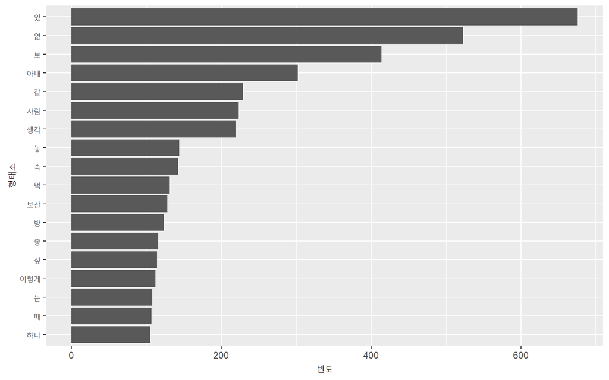

```r
leesang.tagged %>%
  count(word, sort = TRUE) %>%
  filter(n > 100) %>%
  mutate(word = reorder(word, n)) %>% # R 내장함수인 reorder를 사용하여 word 행을 n의 크기에 따라 배열하기.
  ggplot(aes(n, word)) +
  geom_col() + # 바의 높이로 관찰값의 크기를 나타내는 함수.
  labs(y = "형태소",
       x = "빈도")
```

## (6) 이상, 이효석, 김만중 작품 형태소 출현비율 비교하기

### 1) 작가 간 형태소 출현비율 분석하기

- 이상과 이효석 & 김만중 간 형태소 출현비율 비교하기: 이상은 이효석 및 김만중과 비교했을 때 어떤 단어를 더 많이 혹은 덜 사용하는가?

```r
# 정규화 실시 및 불용어 제거하기.
novel.tidy <- novels %>%
  filter(author %in% c("김만중", "이효석", "이상")) %>%
  mutate(text_segment = enc2utf8(content)) %>%
  unnest_tokens(word, text_segment, token = RcppMeCab::pos) %>% # 토큰화 빙식으로 RcppMeCab 패키지의 형태소 분석 함수인 pos를 투입.
  separate(word, into = c("word", "pos"), sep = "/") %>% # "/"를 기준으로 word 열과 pos 열로 나누기.
  filter(!str_detect(pos, "j[a-z]{1,3}|e[a-z]{1,3}|s[a-z]{1,3}")) %>% # 조사, 어미, 기호 제외.
  unnest_tokens(word, word, token = "words", strip_punct = T) %>% # 형태소 단위로 토큰화.
  anti_join(stop_words_korean) # 불용어 목록 출현 단어 제거하기.
novel.tidy
```

```
## # A tibble: 65,834 x 7
##    title                  author source                content  nsyl word  pos
##    <chr>                  <chr>  <chr>                 <chr>   <int> <chr> <chr>
##  1 공포(恐怖)의 기록(記錄 이상   " 매일신보 , 1937.4.~ " 서 ~   9493 서    nng
##  2 공포(恐怖)의 기록(記錄 이상   " 매일신보 , 1937.4.~ " 서 ~   9493 생활  nng
##  3 공포(恐怖)의 기록(記錄 이상   " 매일신보 , 1937.4.~ " 서 ~   9493 오래  mag
##  4 공포(恐怖)의 기록(記錄 이상   " 매일신보 , 1937.4.~ " 서 ~   9493 생활  nng
##  5 공포(恐怖)의 기록(記錄 이상   " 매일신보 , 1937.4.~ " 서 ~   9493 갖    vv
##  6 공포(恐怖)의 기록(記錄 이상   " 매일신보 , 1937.4.~ " 서 ~   9493 단편  nng
##  7 공포(恐怖)의 기록(記錄 이상   " 매일신보 , 1937.4.~ " 서 ~   9493 찾아~ vv
##  8 공포(恐怖)의 기록(記錄 이상   " 매일신보 , 1937.4.~ " 서 ~   9493 생활  nng
##  9 공포(恐怖)의 기록(記錄 이상   " 매일신보 , 1937.4.~ " 서 ~   9493 비슷  xr
## 10 공포(恐怖)의 기록(記錄 이상   " 매일신보 , 1937.4.~ " 서 ~   9493 오직  nng
## # ... with 65,824 more rows
```

```r
# 이상과 이효석/김만중 간 형태소 출현비율 비교하기.
novel.freq <- novel.tidy %>%
  count(author, word) %>% # 저자별 word(형태소) 빈도 구하기.
  group_by(author) %>% # 저자별로 grouping하기.
  mutate(proportion = n / sum(n)) %>%  # 형태소 출현 비율 구하기.
  select(-n) %>% # n 열 삭제하기.
  pivot_wider(names_from = author, values_from = proportion) %>% # 각 저자가 하나의 열이 되고 비율이 값이 되도록 데이터프레임 변형하기
  pivot_longer(c(`김만중`, `이효석`), # 이상 vs. 김만중 & 이효석을 비교하기 위해 이상 열을 따로 두기.
               names_to = "author", values_to = "proportion")
novel.freq
```

```
## # A tibble: 24,926 x 4
##    word   이상 author proportion
##    <chr> <dbl> <chr>       <dbl>
##  1 几       NA 김만중  0.0000671
##  2 几       NA 이효석 NA
##  3 妤       NA 김만중  0.0000671
##  4 妤       NA 이효석 NA
##  5 婕       NA 김만중  0.0000671
##  6 婕       NA 이효석 NA
##  7 媵       NA 김만중  0.0000671
##  8 媵       NA 이효석 NA
##  9 氅衣     NA 김만중  0.0000671
## 10 氅衣     NA 이효석 NA
## # ... with 24,916 more rows
```

```r
# 고빈도 형태소 출현비율 비교하기.
novel.freq %>%
  arrange(desc(`이상`)) # 이상은 "아내"의 사용비율이 상대적으로 매우 높음.
```

```
## # A tibble: 24,926 x 4
##    word     이상 author proportion
##    <chr>   <dbl> <chr>       <dbl>
##  1 있    0.0237  김만중   0.0158
##  2 있    0.0237  이효석   0.0212
##  3 없    0.0183  김만중   0.00724
##  4 없    0.0183  이효석   0.0148
##  5 보    0.0145  김만중   0.0149
##  6 보    0.0145  이효석   0.00834
##  7 아내  0.0106  김만중   0.000537
##  8 아내  0.0106  이효석   0.000223
##  9 같    0.00803 김만중   0.00644
## 10 같    0.00803 이효석   0.00625
## # ... with 24,916 more rows
```

### 2) 작가 간 형태소 출현비율 상관 계산하기

- 상관분석 시행
  - 이상 vs. 이효석/김만중 간에 형태소 출현비율이 얼마나 높은 상관관계를 나타내는지 확인.
  - 분석결과: 이상의 형태소 출현비율은 조선시대 작가 김만중보다 동시대 작가 이효석과 더 높은 상관을 나타냄.

```r
# 이상 vs. 김만중 비교
cor.test(data = novel.freq[novel.freq$author == "김만중",], # 저자가 "김만중"인 데이터만 서브세팅함.
         ~ proportion + `이상`) # 상관분석을 하고자 하는 두 개의 변수. 여기서는 "이상"의 형태소 출현비율과 "김만중"의 형태소 출현비율.
```

```
##
##  Pearson's product-moment correlation
##
## data:  proportion and 이상
## t = 31.457, df = 1287, p-value < 2.2e-16
## alternative hypothesis: true correlation is not equal to 0
## 95 percent confidence interval:
##  0.6272780 0.6890921
## sample estimates:
##       cor
## 0.6592976
```

```r
# 이상 vs. 이효석 비교
cor.test(data = novel.freq[novel.freq$author == "이효석",], # 저자가 "이효석"인 데이터만 서브세팅함.
         ~ proportion + `이상`) # 상관분석을 하고자 하는 두 개의 변수. 여기서는 "이상"의 형태소 출현비율과 "이효석"의 형태소 출현비율.
```

```
##
##  Pearson's product-moment correlation
##
## data:  proportion and 이상
## t = 77.374, df = 2431, p-value < 2.2e-16
## alternative hypothesis: true correlation is not equal to 0
## 95 percent confidence interval:
##  0.8314559 0.8544344
## sample estimates:
##       cor
## 0.8433302
```

### 3) 결과 시각화하기

- **ggplot2** 패키지를 통한 시각과: 이상과 김만중, 이상과 이효석 간 공기빈도가 높은 단어와 그렇지 않은 단어의 분포 패턴을 시각화할 수 있음.

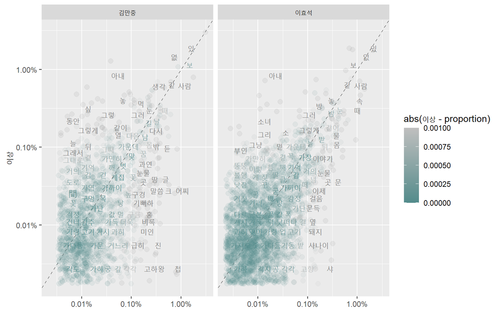

```r
library(scales)

ggplot(novel.freq, aes(x = proportion, y = `이상`, # 미학적 맵핑에서 x는 다른 두 작가, y는 "이상"의 형태소 출현비율을 가리킴.
                      color = abs(`이상` - proportion))) + # 미학적 맵핑에서 color는 "이상"에서 다른 작가의 형태소 출현비율을 뺀 값의 절대값을 가리킴.
  geom_abline(color = "gray40", lty = 2) + # 회귀선의 색상과 선 모양 지정하기.
  geom_jitter(alpha = 0.1, size = 2.5, width = 0.3, height = 0.3) + # geom_jitter 함수로 관찰값을 동그라미로 나타냄. 동그라미의 크기와 형태 지정하기.
  geom_text(aes(label = word), check_overlap = TRUE, vjust = 1.5) + # geom_text 함수로 텍스트도 아울러 시각화함.
  scale_x_log10(labels = percent_format()) + # x축은 밑이 10인 로그로 스케일을 변환. 레이블은 퍼센트 단위로 나타냄(그러나 실제로 로그화된 값이 그림에 제시되는 것은 아님!).
  scale_y_log10(labels = percent_format()) + # y축도 밑이 10인 로그로 스케일을 변환. 레이블은 퍼센트 단위로 나타냄(그러나 실제로 로그화된 값이 그림에 제시되는 것은 아님!).
  scale_color_gradient(limits = c(0, 0.001), # scale_color_gradient는 두 가지 색상으로 스케일을 표현하는 함수. limits 논항을 통해 스케일의 한도(이상 - 다른 작가의 형태소 출현비율 값의 한도)를 0과 0.001 사이로 한정.
                       low = "darkslategray4", high = "gray75") + # 두 가지 색상을 통해 그라데이션을 나타냄. 값이 낮을수록 low, 높은 쪽알수록 high에 할당한 색상에 가깝게 표현됨.
  facet_wrap(~ author, ncol = 2) + # 저자별로 도표를 다면 출력하기.
  labs(y = "이상", x = NULL) # y축 레이블만 "이상"으로 지정하기.
```

# 2. tidy 텍스트로 감성분석(sentiment analysis) 수행하기

## (1) 한국어 감정사전

### 1) 군산대학교(KNU) 감정사전

#### A. 소개

- 제작자: 군산대학교 소프트웨어융합공학과 Data Intelligence Lab에서 개발한 한국어 감정 사전.
- 웹사이트: [링크](https://github.com/park1200656/KnuSentiLex).
- 사전 구축에 사용된 자료 출처
  - 국립국어원 표준국어대사전의 뜻풀이 분석을 통한 긍부정 추출.
  - 김은영(2004)의 긍부정어 목록.
  - SentiWordNet 및 SenticNet-5.0에서 주로 사용되는 긍부정어 번역.
  - 사전 구축 당시 온라인에서 많이 사용되던 축약어 및 긍부정 이모티콘 목록.
- 특징
  - 표준국어대사전을 구성하는 각 단어의 뜻풀이를 분석하여 긍부정어를 추출.
  - 1-그램, 2-그램, n-그램(어구, 문형), 축약어, 이모티콘 등의 다양한 종류의 긍부정어 포함.
  - 영화, 음악, 자동차 등 어떤 영역(domain)에도 사용될 수 있는 보편적인 긍부정어로 구성.
- 구성
  - 매우 긍정(2점): 2,597개.
  - 긍정(1점): 2,266개.
  - 중립(0점): 154개.
  - 부정(-1점): 5,029개.
  - 매우 부정(-2점): 4,797개.
- 파일 링크
  - JSON 파일: SentiWord_info.json
  - txt 파일: SentiWord_Dict.txt

#### B. 극성 변환하기

- 사전의 내용: 감성사전에 포함된 긍정단어와 부정단어의 분포 살펴보기.

```r
# JSON 파일을 R로 반입하는 패키지 jsonlite 불러들이기.
library(jsonlite)

# 감성사전 JSON 파일 R로 반입하기.
sentiment.json <- fromJSON("texts/sentiment_dic/SentiWord_info.json", simplifyDataFrame = T)

# 긍정단어와 부정단어의 빈도 확인하기.
sentiment.json %>%
  count(polarity)
```

```
##   polarity    n
## 1       -1 5030
## 2       -2 4799
## 3        0  154
## 4        1 2269
## 5        2 2602
```

- 극성의 변환: 분석에 용이하도록 극성을 긍정, 중립, 부정 세 가지 범주로 구분하기.

```r
# 극성을 긍정, 부정, 중립 세 범주로 변환하기.
sentiment.json.1 <- sentiment.json %>%
  mutate(sentiment = case_when(polarity >= 1 ~ "POS",
                               polarity < 0 ~ "NEG",
                               TRUE ~ "NEU")
         ) %>%
  as_tibble()

# 극성별 빈도 분석하기.
sentiment.json.1 %>%
  count(sentiment)
```

```
## # A tibble: 3 x 2
##   sentiment     n
##   <chr>     <int>
## 1 NEG        9829
## 2 NEU         154
## 3 POS        4871
```

#### C. 정규화하기

- 1단계: JSON 파일의 word_root(어근) 열 사용하기. 조사와 어미가 제거되어 정규화된 토큰 단위로 사용 가능.
- 2단계: 1-그램 감정어만 추출(2-그램 이상 감정어 제거).
- 3단계: 용언 맨끝의 종결어미 “-다” 제거.

```r
# word_root 열 살펴보기.
sentiment.json.1
```

```
## # A tibble: 14,854 x 4
##    word  word_root polarity sentiment
##    <chr> <chr>     <chr>    <chr>
##  1 (-;   (         1        POS
##  2 (;_;) (;_;)     -1       NEG
##  3 (^^)  (^^)      1        POS
##  4 (^-^) (^-^)     1        POS
##  5 (^^*  (         1        POS
##  6 (^_^) (^_^)     1        POS
##  7 (^_^; (         -1       NEG
##  8 (^o^) (^o^)     1        POS
##  9 (-_-) (-_-)     -1       NEG
## 10 (T_T) (T_T)     -1       NEG
## # ... with 14,844 more rows
```

```r
# 2-그램 감정어 제거하기 및 용언 맨끝의 종결어미 "-다" 제거하기.
sentiment.json.2 <- sentiment.json.1 %>%
  filter(!str_detect(word, " ")) %>% # 2-그램 감정어 제거하기.
  mutate(word = str_replace_all(word, "다$", "")) # 용언 맨끝의 "-다" 제거하기
sentiment.json.2
```

```
## # A tibble: 6,463 x 4
##    word  word_root polarity sentiment
##    <chr> <chr>     <chr>    <chr>
##  1 (-;   (         1        POS
##  2 (;_;) (;_;)     -1       NEG
##  3 (^^)  (^^)      1        POS
##  4 (^-^) (^-^)     1        POS
##  5 (^^*  (         1        POS
##  6 (^_^) (^_^)     1        POS
##  7 (^_^; (         -1       NEG
##  8 (^o^) (^o^)     1        POS
##  9 (-_-) (-_-)     -1       NEG
## 10 (T_T) (T_T)     -1       NEG
## # ... with 6,453 more rows
```

### 2) 손선주, 박미숙, 박지은, 손진훈 (2012) 감정사전

#### B. 정규화하기

- 1단계: 1-그램 감정어만 추출(2-그램 이상 감정어 제거).
- 2단계: 용언 맨끝의 종결어미 “-다” 제거.

```r
# readxl 패키지로 엑셀 파일 R로 반입하기.
library(readxl)

# 2-그램 감정어 제거하기 및 용언 맨끝의 종결어미 "-다" 제거하기.
sentiment.son <- read_excel("texts/sentiment_dic/한국어 감정표현단어의 추출과 범주화_손선주 외 (2012)_부록 정리_429단어.xlsx") %>%
  filter(!str_detect(`단어`, " ")) %>%
  mutate(`단어` = str_replace_all(`단어`, "다$", ""))
sentiment.son
```

```
## # A tibble: 417 x 6
##     번호 단어     `감정 범주` `빈도(%)` `감정 강도 M` `감정 강도 STD`
##    <dbl> <chr>    <chr>           <dbl>         <dbl>           <dbl>
##  1     1 가련하   슬픔             88.8          5.62            2.36
##  2     3 가슴앓이 슬픔             90            7.75            1.98
##  3     4 가엾     슬픔             87.5          6.26            2.59
##  4     5 각박하   슬픔             42.5          5.87            2.47
##  5     6 간절하   슬픔             57.5          4.95            2.72
##  6     7 걱정하   슬픔             66.3          4.55            2.29
##  7     8 고달프   슬픔             77.5          5.66            2.79
##  8     9 고독하   슬픔             70            6.29            2.68
##  9    10 곤욕스럽 슬픔             32.5          4.62            2.71
## 10    11 공허하   슬픔             57.5          5.74            2.54
## # ... with 407 more rows
```

#### C. 극성 변환하기

```r
sentiment.son.1 <- sentiment.son %>%
  mutate(sentiment = case_when(`감정 범주` %in% c("기쁨, 흥미") ~ "POS",
                               `감정 범주` %in% c("슬픔", "공포", "분노", "혐오", "지루함", "통증") ~ "NEG",
                               `감정 범주` %in% c("중성") ~ "NEU")) %>%
  rename(word = `단어`, category = `감정 범주`) %>%
  select(-1, -4, -5, -6)
sentiment.son.1
```

```
## # A tibble: 417 x 3
##    word     category sentiment
##    <chr>    <chr>    <chr>
##  1 가련하   슬픔     NEG
##  2 가슴앓이 슬픔     NEG
##  3 가엾     슬픔     NEG
##  4 각박하   슬픔     NEG
##  5 간절하   슬픔     NEG
##  6 걱정하   슬픔     NEG
##  7 고달프   슬픔     NEG
##  8 고독하   슬픔     NEG
##  9 곤욕스럽 슬픔     NEG
## 10 공허하   슬픔     NEG
## # ... with 407 more rows
```

### 3) KOSAC(Korean Sentiment Analysis Corpus: 한국어 감정 및 의견 분석 코퍼) 감정사전

#### A. 소개

- 제작자: 김문형, 장하연, 조유미, 신효필(2013).
- 웹사이트: [링크](http://word.snu.ac.kr/kosac/index.php).
- 사전 구축에 사용된 자료 출처
  - 세종 구문분석 말뭉치에서 선별한 332개 신문 기사와 7,744문장을 대상으로 17,582개의 감정표현 주석을 붙임.
  - 기계학습을 통한 극성분류 실험 결과 82.52%의 정확도 나타냄.
- 특징
  - 감정범주를 긍정, 부정, 중립 등 총 3가지로 분류.
  - 2-그램 이상의 감정어 다수 존재.
- 구성
  - 긍정단어: 7367개.
  - 부정단어: 6994개.
  - 중립단어: 1005개.
  - 복합단어: 439개.
  - 기타: 557개.

#### B. 정규화하기

- 1단계: 1-그램 감정어만 추출(2-그램 이상 감정어 제거).
- 2단계: 조사, 어미, 기호 제거.

```r
# KOSAC 감정사전 R로 반입하기.
sentiment.kosac <- read_csv("texts/sentiment_dic/KOSAC_polarity.csv")

sentiment.kosac.1 <- sentiment.kosac %>%
  filter(!str_detect(ngram, ";|\\*"), # 2-그램 이상 감정어 및 * 표시가 붙은 감정어 제거.
         !str_detect(max.value, "None|COMP")) %>% # 3가지 극성에 포함되지 않는 단어 제거.
  mutate(max.value = case_when(max.value == "NEUT" ~ "NEU",
                               T ~ max.value)) %>%
  separate(ngram, into = c("word", "pos"), sep = "/") %>%
  mutate(word_tagged = str_c(word, "/", pos)) %>% # 형태소 분석 감정어 열 추가하기.
  filter(!str_detect(pos, "J[A-Z]{1,3}|E[A-Z]{1,3}|S[A-Z]{1,3}")) %>% # 조사, 어미, 기호 제거.
  rename(sentiment = max.value) %>%
  select(-c(3:8), -10)
sentiment.kosac.1
```

```
## # A tibble: 2,994 x 4
##    word   pos   sentiment word_tagged
##    <chr>  <chr> <chr>     <chr>
##  1 가     VV    NEG       가/VV
##  2 가     VX    POS       가/VX
##  3 가격   NNG   POS       가격/NNG
##  4 가까이 MAG   NEG       가까이/MAG
##  5 가깝   VA    NEG       가깝/VA
##  6 가꾸   VV    POS       가꾸/VV
##  7 가늠   NNG   POS       가늠/NNG
##  8 가능   NNG   NEU       가능/NNG
##  9 가능   XR    NEG       가능/XR
## 10 가도   NNG   POS       가도/NNG
## # ... with 2,984 more rows
```

```r
# 극성 범주별 단어의 수 확인하기.
sentiment.kosac.1 %>%
  count(sentiment)
```

```
## # A tibble: 3 x 2
##   sentiment     n
##   <chr>     <int>
## 1 NEG        1391
## 2 NEU         167
## 3 POS        1436
```

## (2) `inner_join` 함수로 감성분석 수행하기

### 1) 트위터로 분석대상 텍스트 수집하기

- **rtweet** 패키지를 사용하여 “윤석열”, “문재인” 키워드로 최신 트윗 1000건씩 수집하기.

```r
# 한글 문자열을 utf8로 인코딩해주는 패키지 불러오기.
library(base64enc)

# rtweet 패키지 불러오기.
library(rtweet)

# 키워드 인코딩하기.
keyword.yoon <- enc2utf8("윤석열")
keyword.moon <- enc2utf8("문재인")

# 키워드별 트윗 수집하기.
rt.yoon <-  search_tweets(keyword.yoon, n = 1000, include_rts = FALSE,
                          retryonratelimit = FALSE) %>%  # 리트윗은 제외.
  select(1:5) %>%
  mutate(keyword = "윤석열")
rt.yoon
```

```
## # A tibble: 895 x 6
##    user_id             status_id   created_at          screen_name text  keyword
##    <chr>               <chr>       <dttm>              <chr>       <chr> <chr>
##  1 1572096768489422851 1576746465~ 2022-10-03 01:30:26 drfj695804~ "이~  윤석열
##  2 259078950           1576746354~ 2022-10-03 01:30:00 JSKjohan    ".\n~ 윤석열
##  3 259078950           1576704819~ 2022-10-02 22:44:57 JSKjohan    ".\n~ 윤석열
##  4 259078950           1576710587~ 2022-10-02 23:07:52 JSKjohan    ".\n~ 윤석열
##  5 726405994893320192  1576746287~ 2022-10-03 01:29:44 shead_game  "우~  윤석열
##  6 224986167           1576746243~ 2022-10-03 01:29:33 Coffeedaoh  "[자~ 윤석열
##  7 861182534           1576745500~ 2022-10-03 01:26:36 jangjo3016  "1분~ 윤석열
##  8 861182534           1576746124~ 2022-10-03 01:29:05 jangjo3016  "잘~  윤석열
##  9 1572738107283505159 1576742894~ 2022-10-03 01:16:15 ordykiforce "윤~  윤석열
## 10 1572738107283505159 1576746090~ 2022-10-03 01:28:57 ordykiforce "나~  윤석열
## # ... with 885 more rows
```

```r
rt.moon <-  search_tweets(keyword.moon, n = 1000, include_rts = FALSE,
                          retryonratelimit = FALSE) %>% # 리트윗은 제외.
  select(1:5) %>%
  mutate(keyword = "문재인")
rt.moon
```

```
## # A tibble: 955 x 6
##    user_id             status_id   created_at          screen_name text  keyword
##    <chr>               <chr>       <dttm>              <chr>       <chr> <chr>
##  1 1527075340765433856 1576746528~ 2022-10-03 01:30:41 ysyvictory  "문~  문재인
##  2 1527075340765433856 1576584122~ 2022-10-02 14:45:20 ysyvictory  "@mi~ 문재인
##  3 1527075340765433856 1576743468~ 2022-10-03 01:18:32 ysyvictory  "이~  문재인
##  4 1527075340765433856 1576746074~ 2022-10-03 01:28:53 ysyvictory  "@ch~ 문재인
##  5 1527075340765433856 1576743221~ 2022-10-03 01:17:33 ysyvictory  "@wo~ 문재인
##  6 1037772387570208768 1576746416~ 2022-10-03 01:30:14 CHM28977    "@JE~ 문재인
##  7 1037772387570208768 1576601869~ 2022-10-02 15:55:52 CHM28977    "[#~  문재인
##  8 1037772387570208768 1576739801~ 2022-10-03 01:03:57 CHM28977    "문~  문재인
##  9 69549657            1576746361~ 2022-10-03 01:30:01 JAMHAHAHA80 "문~  문재인
## 10 1194033720589598720 1576746177~ 2022-10-03 01:29:18 jj0lly      "문~  문재인
## # ... with 945 more rows
```

```r
# 두 트윗 모음 합치기.
rt.whole <- bind_rows(rt.yoon, rt.moon)
rt.whole
```

```
## # A tibble: 1,850 x 6
##    user_id             status_id   created_at          screen_name text  keyword
##    <chr>               <chr>       <dttm>              <chr>       <chr> <chr>
##  1 1572096768489422851 1576746465~ 2022-10-03 01:30:26 drfj695804~ "이~  윤석열
##  2 259078950           1576746354~ 2022-10-03 01:30:00 JSKjohan    ".\n~ 윤석열
##  3 259078950           1576704819~ 2022-10-02 22:44:57 JSKjohan    ".\n~ 윤석열
##  4 259078950           1576710587~ 2022-10-02 23:07:52 JSKjohan    ".\n~ 윤석열
##  5 726405994893320192  1576746287~ 2022-10-03 01:29:44 shead_game  "우~  윤석열
##  6 224986167           1576746243~ 2022-10-03 01:29:33 Coffeedaoh  "[자~ 윤석열
##  7 861182534           1576745500~ 2022-10-03 01:26:36 jangjo3016  "1분~ 윤석열
##  8 861182534           1576746124~ 2022-10-03 01:29:05 jangjo3016  "잘~  윤석열
##  9 1572738107283505159 1576742894~ 2022-10-03 01:16:15 ordykiforce "윤~  윤석열
## 10 1572738107283505159 1576746090~ 2022-10-03 01:28:57 ordykiforce "나~  윤석열
## # ... with 1,840 more rows
```

### 2) `inner_join` 함수로 감성분석 수행하기

- `inner_join` 함수로 감성분석 수행하기
  - KNU 한국어 감정어 사전 수록어와 목표 텍스트 단어 간 교집합 찾기.
  - 목표 텍스트 단어 열에서 감정어 사전 수록 단어와 일치하는 것만 남기고 나머지는 모두 제거.

```r
# 상위 감정단어 20개 빈도 확인하기.
rt.whole.1 <- rt.whole %>%
  mutate(text = enc2utf8(text)) %>%
  unnest_tokens(word, text, token = RcppMeCab::pos) %>% # 토큰화 빙식으로 RcppMeCab 패키지의 형태소 분석 함수인 pos를 투입.
  separate(word, into = c("word", "pos"), sep = "/") %>% # word 문자열의 "/"을 기준으로 word 열과 pos 열로 나누기.
  inner_join(sentiment.json.2, by = c("word" = "word_root")) %>% # inner_join 함수를 사용하여 rt.whole의 word 열과 감성사전(sentiment.json.2)의 word_root 열을 병합하기. 이때 감정어 사전 수록 단어와 일치하는 단어만 남기고 나머지는 모두 제거.
  group_by(keyword) %>% # keyword(윤석열, 문재인)별로 grouping하기.
  count(word, polarity , sort = T) %>% # polarity별 word의 빈도 분석 후 내림차순으로 배열.
  filter(str_length(word) > 1) %>% # word의 음절 길이가 1 이상인 것만 추출하기.
  mutate(word = reorder(word, n)) %>% # word 행을 n의 크기에 따라 배열하기.
  slice_head(n = 20) # 상위 20개 행 서브세팅하기.
rt.whole.1
```

```
## # A tibble: 40 x 4
## # Groups:   keyword [2]
##    keyword word  polarity     n
##    <chr>   <fct> <chr>    <int>
##  1 문재인  사랑  2          228
##  2 문재인  걱정  -1         168
##  3 문재인  잘못  -2         136
##  4 문재인  특권  2          109
##  5 문재인  감사  2           96
##  6 문재인  아니  -2          92
##  7 문재인  불쾌  -2          84
##  8 문재인  거부  -1          79
##  9 문재인  거부  -2          79
## 10 문재인  범죄  -2          72
## # ... with 30 more rows
```

### 3) **ggplot2** 패키지로 분석결과 시각화하기

- 키워드(윤석열 vs. 문재인) 간 감성 비교: 감정단어 빈도 비교 시각화하기.

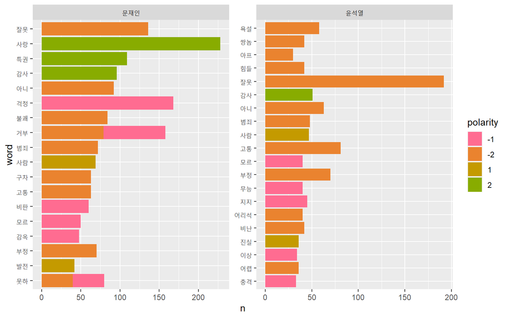

```r
rt.whole.1 %>%
  ggplot(aes(n, word, fill = polarity)) + # polarity(극성)별로 색상을 달리 칠하기.
  geom_col() + # 바의 높이로 관찰값의 크기를 나타내는 함수.
  scale_fill_hue(h = c(0, 100)) + # 칠하는 색상의 유형을 지정하기.
  facet_wrap(~ keyword, scales = "free") # keyword(윤석열, 문재인)에 따라 도표를 다면 출력하기.
```

## (3) 3개 감성사전 비교하기

- KNU 사전 기반 감성분석 수행하기: 극성이 수치(-2, -1, 0, 1, 2)로 표현되어 있음.

```r
KNU <- rt.whole %>%
  mutate(text = enc2utf8(text)) %>% # text 열을 UTF-8로 인코딩하기.
  unnest_tokens(word, text, token = RcppMeCab::pos) %>% # RcppMeCab 패키지의 pos 함수로 text를 토큰화하기.
  separate(word, into = c("word", "pos"), sep = "/") %>% # word의 문자열을 "/"를 기준으로 word 열과 pos 열로 나누기.
  filter(str_length(word) > 1, # word의 음절 길이가 1이상인 경우만 추출하기.
         !str_detect(word, "\\W|부정")) %>% # word가 글자 또는 숫자가 아닌 경우는 제외하기.
  inner_join(sentiment.json.2, by = c("word" = "word_root")) %>% #  rt.whole과 감정어 사전(sentiment.json.2)의 사전을 word 열(감정어 사전은 word_root)을 기준으로 결합하기. 이때 감정어 사전 비수록 단어는 모두 제외됨.
  group_by(keyword) %>% # keyword(윤석열, 문재인)에 따라 grouping하기.
  summarise(sentiment = sum(as.numeric(as.character(polarity)))) %>% # 현재 polarity가 문자로 되어 있으므로, 숫자로 변환한 뒤 총 감성점수 합산해주기.
  mutate(method = "KNU") # 감정어 사전명 열 추가하기.
KNU
```

```
## # A tibble: 2 x 3
##   keyword sentiment method
##   <chr>       <dbl> <chr>
## 1 문재인      -2191 KNU
## 2 윤석열      -2931 KNU
```

- 손선주 외 3인(2012) 사전 기반 감성분석 수행하기: 극성이 문자열(POS, NEU, NEG)로 표현되어 있음.

```r
SON <- rt.whole %>%
  mutate(text = enc2utf8(text)) %>% # text 열을 UTF-8로 인코딩하기.
  unnest_tokens(word, text, token = RcppMeCab::pos) %>% # RcppMeCab 패키지의 pos 함수로 text를 토큰화하기.
  separate(word, into = c("word", "pos"), sep = "/") %>% # word의 문자열을 "/"를 기준으로 word 열과 pos 열로 나누기.
  filter(str_length(word) > 1, # word의 음절 길이가 1이상인 경우만 추출하기.
         !str_detect(word, "\\W|부정")) %>% # word가 글자 또는 숫자가 아닌 경우는 제외하기.
  inner_join(sentiment.son.1, by = "word") %>% # rt.whole과 감정어 사전(sentiment.son.1)의 사전을 word 열을 기준으로 결합하기. 이때 감정어 사전 비수록 단어는 모두 제외됨.
  mutate(method = "SON") # 감정어 사전명 열 추가하기.
SON
```

```
## # A tibble: 139 x 10
##    user_id         status_id created_at          screen_name keyword word  pos
##    <chr>           <chr>     <dttm>              <chr>       <chr>   <chr> <chr>
##  1 259078950       15767105~ 2022-10-02 23:07:52 JSKjohan    윤석열  나쁘  va
##  2 861182534       15767455~ 2022-10-03 01:26:36 jangjo3016  윤석열  개새~ nng
##  3 370396042       15767449~ 2022-10-03 01:24:21 kimsunchul~ 윤석열  아프  va
##  4 168484184       15767373~ 2022-10-03 00:54:03 joom1217    윤석열  개새~ nng
##  5 99116361539788~ 15767424~ 2022-10-03 01:14:23 brainsario~ 윤석열  아프  va
##  6 1030951790      15767409~ 2022-10-03 01:08:19 dddansori2  윤석열  역겹  va
##  7 11346779873941~ 15767364~ 2022-10-03 00:50:48 PONNICHI1   윤석열  겁나  vv+ec
##  8 15061057647250~ 15767284~ 2022-10-03 00:18:42 FarmerSaxo~ 윤석열  아깝  va
##  9 79037720182050~ 15767359~ 2022-10-03 00:48:39 Sweetheart~ 윤석열  부끄~ va
## 10 79037720182050~ 15767356~ 2022-10-03 00:47:39 Sweetheart~ 윤석열  울부~ vv
## # ... with 129 more rows, and 3 more variables: category <chr>,
## #   sentiment <chr>, method <chr>
```

- KOSAC 사전 기반 감성분석 수행하기: 극성이 문자열(POS, NEU, NEG)로 표현되어 있음.

```r
KOSAC <- rt.whole %>%
  mutate(text = enc2utf8(text)) %>% # text 열을 UTF-8로 인코딩하기.
  unnest_tokens(word, text, token = RcppMeCab::pos) %>% # RcppMeCab 패키지의 pos 함수로 text를 토큰화하기.
  separate(word, into = c("word", "pos"), sep = "/") %>% # word의 문자열을 "/"를 기준으로 word 열과 pos 열로 나누기.
  mutate(word_tagged = str_c(word, "/", toupper(pos))) %>% # 형태소 분석 감정어 열 추가하기.
  filter(str_length(word) > 1, # word의 음절 길이가 1이상인 경우만 추출하기.
         !str_detect(word, "\\W|부정")) %>% # word가 글자 또는 숫자가 아닌 경우는 제외하기.
  inner_join(sentiment.kosac.1, by = "word") %>% # rt.whole과 감정어 사전(sentiment.kosac.1)의 사전을 word 열을 기준으로 결합하기. 이때 감정어 사전 비수록 단어는 모두 제외됨.
  mutate(method = "KOSAC") # 감정어 사전명 열 추가하기.
KOSAC
```

```
## # A tibble: 8,726 x 12
##    user_id         status_id created_at          screen_name keyword word  pos.x
##    <chr>           <chr>     <dttm>              <chr>       <chr>   <chr> <chr>
##  1 15720967684894~ 15767464~ 2022-10-03 01:30:26 drfj695804~ 윤석열  새끼  nng
##  2 15720967684894~ 15767464~ 2022-10-03 01:30:26 drfj695804~ 윤석열  누구  np
##  3 259078950       15767463~ 2022-10-03 01:30:00 JSKjohan    윤석열  다음  nng
##  4 259078950       15767463~ 2022-10-03 01:30:00 JSKjohan    윤석열  해명  nng
##  5 259078950       15767463~ 2022-10-03 01:30:00 JSKjohan    윤석열  아니  vcn
##  6 259078950       15767463~ 2022-10-03 01:30:00 JSKjohan    윤석열  기대  nng
##  7 259078950       15767048~ 2022-10-02 22:44:57 JSKjohan    윤석열  현재  nng
##  8 259078950       15767048~ 2022-10-02 22:44:57 JSKjohan    윤석열  심리  nng
##  9 259078950       15767048~ 2022-10-02 22:44:57 JSKjohan    윤석열  상태  nng
## 10 259078950       15767048~ 2022-10-02 22:44:57 JSKjohan    윤석열  행사  nng
## # ... with 8,716 more rows, and 5 more variables: word_tagged.x <chr>,
## #   pos.y <chr>, sentiment <chr>, word_tagged.y <chr>, method <chr>
```

- 극성이 문자열로 표현된 손선주 외 3인(2012)과 KOSAC 감성분석 결과 병합하기.

```r
SON_and_KOSAC <- bind_rows(SON, KOSAC) %>% # SON 티블과 KOSAC 티블 rbind 형식으로 결합하기.
  count(method, keyword, sentiment) %>% # 각 method의 각 keyword의 sentiment별로 빈도 분석하기.
  pivot_wider(names_from = sentiment, # sentiment의 각 유형(POS, NEG)이 개별 열을 구성하도록 만들기.
              values_from = n, # 각 열의 관찰값은 n(빈도)가 됨.
              values_fill = 0) %>% # 관찰값이 없는 경우 0으로 채워넣음.
  mutate(sentiment = POS - NEG) # POS 빈도에서 NEG 빈도를 뺸 값을 sentiment 열로 추가.
SON_and_KOSAC
```

```
## # A tibble: 4 x 7
##   method keyword   NEG   NEU   POS  `NA` sentiment
##   <chr>  <chr>   <int> <int> <int> <int>     <int>
## 1 KOSAC  문재인   2496   111  1990     0      -506
## 2 KOSAC  윤석열   2135   143  1851     0      -284
## 3 SON    문재인     56     0     0     4       -56
## 4 SON    윤석열     78     0     0     1       -78
```

- 분석결과 시각화하기.

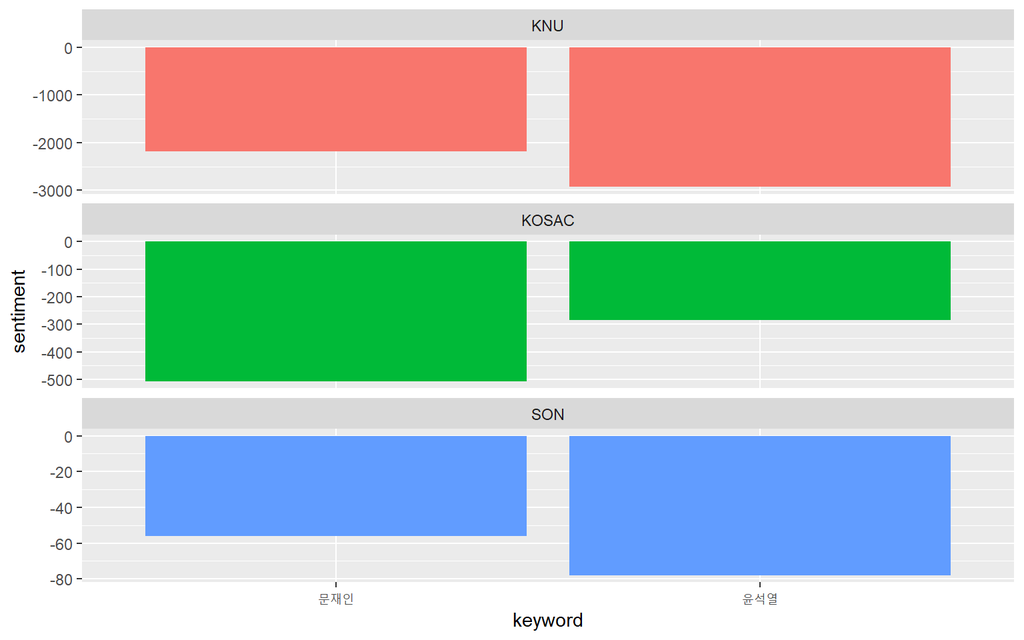

```r
bind_rows(KNU, SON_and_KOSAC) %>%
  ggplot(aes(keyword, sentiment, fill = method)) + # method(감정어 사전 유형)별로 색상을 달리 칠하기.
  geom_col(show.legend = FALSE) + # 바의 높이로 관찰값의 크기를 나타내는 함수.
  facet_wrap(~ method, ncol = 1, scales = "free_y") # method(감정어 사전 유형)에 따라 도표를 다면 출력하기. 열의 수는 한 개. y축 스케일은 따로 규정하지 않음.
```

## (4) 극성별 빈출 단어/형태소

- 극성 및 키워드 별 빈출 단어/형태소 분석하기: KNU 감정어 사전만 예를 들어 살펴보기.

```r
KNU_word_counts <- rt.whole %>%
  mutate(text = enc2utf8(text)) %>% # text 열을 UTF-8로 인코딩하기.
  unnest_tokens(word, text, token = RcppMeCab::pos) %>% # RcppMeCab 패키지의 pos 함수로 text를 토큰화하기.
  separate(word, into = c("word", "pos"), sep = "/") %>% # word의 문자열을 "/"를 기준으로 word 열과 pos 열로 나누기.
  filter(str_length(word) > 1, # word의 음절 길이가 1이상인 경우만 추출하기.
         !str_detect(word, "\\W")) %>%  # word가 글자 또는 숫자가 아닌 경우는 제외하기.
  inner_join(sentiment.json.2, by = c("word" = "word_root")) %>% #  rt.whole과 감정어 사전(sentiment.json.2)의 사전을 word 열(감정어 사전은 word_root)을 기준으로 결합하기. 이때 감정어 사전 비수록 단어는 모두 제외됨.
  group_by(keyword) %>% # keyword(윤석열, 문재인)별로 grouping하기.
  count(word, sentiment, sort = TRUE) # 각 word의 sentiment별로 빈도 분석한 뒤 내림차순으로 표현하기.
KNU_word_counts
```

```
## # A tibble: 976 x 4
## # Groups:   keyword [2]
##    keyword word  sentiment     n
##    <chr>   <chr> <chr>     <int>
##  1 문재인  사랑  POS         264
##  2 윤석열  잘못  NEG         192
##  3 문재인  걱정  NEG         182
##  4 문재인  거부  NEG         158
##  5 문재인  잘못  NEG         136
##  6 문재인  특권  POS         109
##  7 문재인  감사  POS          96
##  8 문재인  아니  NEG          92
##  9 문재인  부정  NEG          90
## 10 윤석열  부정  NEG          90
## # ... with 966 more rows
```

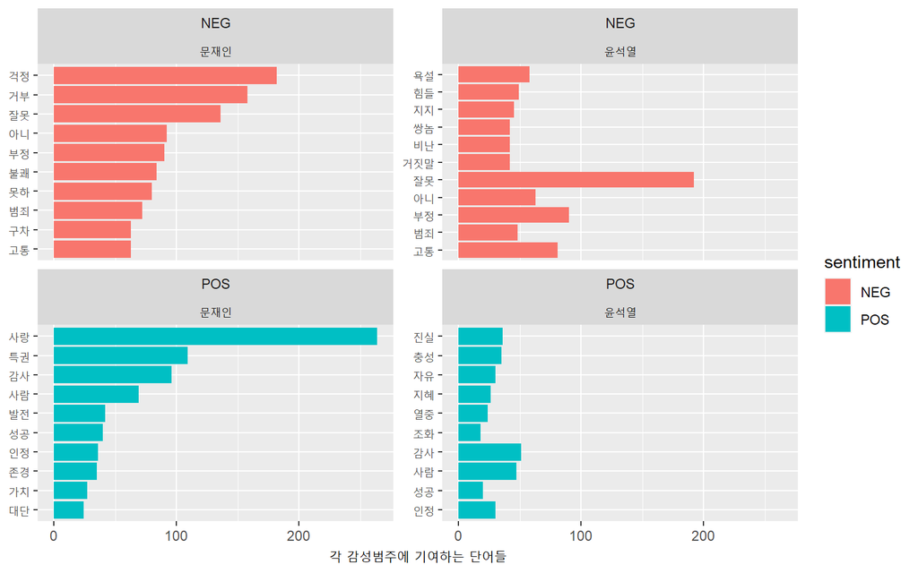

```r
KNU_word_counts %>%
  group_by(sentiment, keyword) %>% # sentiment(POS, NEG)와 keyword(윤석열, 문재인)별로 grouping하기.
  slice_max(n, n = 10) %>% # n(빈도)이 가장 높은 10개 단어만 서브세팅하기.
  mutate(word = reorder(word, n)) %>% # word 행을 n(빈도) 순으로 나열하기.
  filter(sentiment != "NEU") %>% # 중립 단어 제거하기.
  ggplot(aes(n, word, fill = sentiment)) + # sentiment별로 색상을 달리 칠하기.
  geom_col() + # 바의 높이로 관찰값의 크기를 나타내는 함수.
  facet_wrap(~ sentiment + keyword, scales = "free_y") + # sentiment와 keyword별로 다면 출력하기.
  labs(x = "각 감성범주에 기여하는 단어들", # x축 레이블 추가하기.
       y = NULL) # y축 레이블 없애기.
```

- 분석결과 시각화하기: “부정” 단어 제거 시.

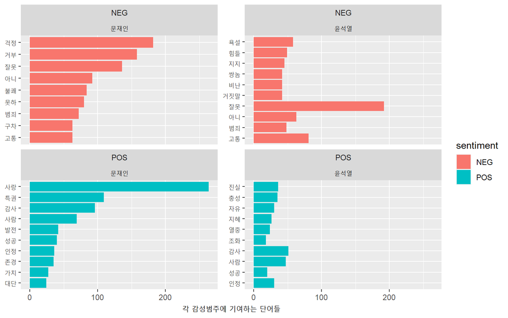

```r
KNU_word_counts %>%
  group_by(sentiment, keyword) %>% # sentiment(POS, NEG)와 keyword(윤석열, 문재인)별로 grouping하기.
  slice_max(n, n = 10) %>% # n(빈도)이 가장 높은 10개 단어만 서브세팅하기.
  mutate(word = reorder(word, n)) %>% # word 행을 n(빈도) 순으로 나열하기.
  filter(sentiment != "NEU", # 중립 단어 제거하기.
         !str_detect(word, "부정")) %>% # "부정" 단어 제거하기.
  ggplot(aes(n, word, fill = sentiment)) + # sentiment별로 색상을 달리 칠하기.
  geom_col() + # 바의 높이로 관찰값의 크기를 나타내는 함수.
  facet_wrap(~ sentiment + keyword, scales = "free_y") + # sentiment와 keyword별로 다면 출력하기.
  labs(x = "각 감성범주에 기여하는 단어들", # x축 레이블 추가하기.
       y = NULL) # y축 레이블 없애기.
```

## (5) 워드 클라우드(wordclouds)

- **wordcloud2** 패키지: 다양한 도형의 형태로 빈출단어를 시각화해주는 도구.
- 주요 함수 `wordcloud2`의 논항
  - `data`: 단어와 해당 단어의 빈도 칼럼으로 구성된 데이터프레임.
  - `size`: 폰트 크기. 기본값은 1. 크기가 클수록 단어도 커짐.
  - `fontFamily`: 서체 종류.
  - `color`: 텍스트의 색상. [EX] ‘random-dark’, ‘random-light’ 등.
  - `backgroundColor`:배경색.
  - `shape`: 구름의 모양. [EX] ‘circle’(기본 모양), ‘cardioid’, ‘diamond’, ‘triangle-forward’, ‘triangle’, ‘pentagon’, ‘star’.

```r
# wordcloud2 패키지 불러오기.
library(wordcloud2)

# 윤석열 관련 감정어만 추출하기.
KNU_word_counts.yoon <- KNU_word_counts %>%
  filter(keyword == "윤석열")
KNU_word_counts.yoon
```

```
## # A tibble: 475 x 4
## # Groups:   keyword [1]
##    keyword word  sentiment     n
##    <chr>   <chr> <chr>     <int>
##  1 윤석열  잘못  NEG         192
##  2 윤석열  부정  NEG          90
##  3 윤석열  고통  NEG          81
##  4 윤석열  아니  NEG          63
##  5 윤석열  욕설  NEG          58
##  6 윤석열  감사  POS          51
##  7 윤석열  힘들  NEG          49
##  8 윤석열  범죄  NEG          48
##  9 윤석열  사람  POS          47
## 10 윤석열  지지  NEG          45
## # ... with 465 more rows
```

```r
# 워드클라우드 형태로 시각화하기.
wordcloud2(data = KNU_word_counts.yoon[, c(2,4)],
           color="random-light",
           fontFamily = "Nanum Gothic",
           backgroundColor = "grey",
           shape = "circle")
```

[interactive chart not shown]

# References

길호현. (2018). 텍스트마이닝을 위한 한국어 불용어 목록 연구. **우리말글**, 78, 1-25.

김문형, 장하연, 조유미, & 신효필. (2013). KOSAC (Korean Sentiment Analysis Corpus): 한국어 감정 및 의견 분석 코퍼스. **한국정보과학회 학술발표논문집**, 650-652.

노성화, 김정. (2022). 텍스트마이닝을 위한 한국어 범용 불용어 목록 연구. **한말연구**, 63(13), 1-15.

손선주, 박미숙, 박지은, 손진훈. (2012). 한국어 감정표현단어의 추출과 범주화. **감성과학**, 15(1), 105-120.

안도현. (2022). **R로 하는 텍스트마이닝**. Retrieved September 25, 2022 from https://bookdown.org/ahn_media/bookdown-demo

온병원, 박상민, 나철원. (2018). **KNU 한국어 감성사전.** Retrieved September 25, 2022 from https://github.com/park1200656/KnuSentiLex

Silge, J., & Robinson, D. (2017). *Text mining with R.* Retrieved September 25, 2022 from https://www.tidytextmining.com